# Area

# Area detects when specific nodes enter and exit it

`Area` creates a 3D space that warns you when objects enter or exit it.

In this guide, you’ll learn to:

- Set up an `Area` node and use its key methods and signals.
- Let the player open a chest, read a board, activate a pressure plate, or trigger other interactable objects.
- Attract items like coins towards the player when they’re close.
- Make an enemy pursue the player when the player enters the enemy’s detection area.
- Create hitboxes.
- Create gravity points to suck in other objects.

Contents:

- Setting up an Area node
- Area’s key methods and signals
  - Detecting when bodies and areas enter or leave an area
  - Getting a list of overlapping areas and bodies
  - Affecting gravity for physical objects
- How to use Area in practice
  - Displaying a message automatically near a sign
  - Attracting coins to the player
  - Pursuing a target
  - Opening a door with a pressure plate
  - Attract rigid bodies to a black hole
  - Dealing damage with hitboxes and hurtboxes
  - Opening chests with contextual inputs
- Your questions
  - What can an Area detect?
  - When should I use an Area instead of a StaticBody or KinematicBody?
  - Telling bodies apart
  - What are the different signals for?
  - Determining who handles the action
  - Using a third object to represent interactions

## Setting up an Area node

Before we dive in, it’s important to understand the basic structure of an `Area`.

A functional `Area` consists of three components:

1. The `Area` itself, for detecting entering and exiting objects.
2. One or more `CollisionShape` or `CollisionPolygon` define the 3D space our `Area` occupies.
3. Each `CollisionShape` has a shape resource associated with them (often a `BoxShape` or a `CapsuleShape`), while the `CollisionPolygon` has an array of points representing vertices of a 3D shape.

For more complex shapes, `CollisionShape` has two special resource types: `ConcavePolygonShape` and `ConvexPolygonShape`. For details on using these, see the [Collision Shapes 3D Manual Page](https://docs.godotengine.org/en/stable/tutorials/physics/collision_shapes_3d.html).

You can see the final structure of a complete `Area` scene below.

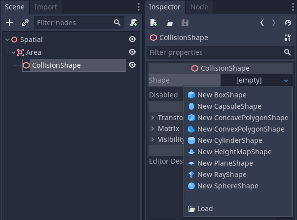

This structure is identical when preparing a `KinematicBody` or `StaticBody`.

It is not uncommon to have issues when you set your collision layers and masks. We have a tutorial dedicated to the topic if you need help: [Using Physics Layers and Masks in Godot 3.1](https://www.gdquest.com/tutorial/godot/2d/physics-layers-and-masks/)

With that out of the way, let’s start!

## Area’s key methods and signals

Most use cases we’ll show you for this node rely on a handful of signals, methods, and properties.

### Detecting when bodies and areas enter or leave an area

A body is a physical body, such as `KinematicBody` or `RigidBody`.

To react when one of these enters and exits an area, connect the `body_entered` and `body_exited` signals:

```
func _on_Area_body_entered(body: Node) -> void:
    print("a node overlapped this area")

func _on_Area_body_exited(body: Node) -> void:
    print("a node stopped overlapping this area")
```

Use `area_entered` and `area_exited` to detect if a different `Area` entered or left this area.

```
func _on_Area_body_entered(area: Area) -> void:
    print("another area overlapped this area")

func _on_Area_body_exited(area: Area) -> void:
    print("another area stopped overlapping this area")
```

### Getting a list of overlapping areas and bodies

To get a list of everything inside an `Area` there are two convenient methods: `get_overlapping_bodies()` and `get_overlapping_areas()`.

These functions are ideal when handling explosives, as they can deal damage to everything within range.

Here’s how you could use `get_overlapping_bodies()` to do so.

```
func explode() -> void:
    for body in get_overlapping_bodies():
        if body.has_method("take_damage"):
            body.take_damage(3)
```

### Affecting gravity for physical objects

An `Area` can override some physics properties for `RigidBody` objects in its space.

To make an area affect physics, set its *Space Override* property. If you have multiple overlapping areas, you can choose the order they apply with the *Priority* property.

By default, the area affects the damping of objects inside it, but you can create an attractor with the `gravity_point` property.

You need to set the *Space Override* property to one of the following options:

- *Combine*: Add physics properties to any calculations.
- *Replace*: Replace physics properties (ignoring lower priority areas).
- *Combine-Replace*: Combines with higher priority areas, ignores lower priority areas.
- *Replace-Combine*: Replaces everything calculated so far but combines with everything after.

You can customize the physics behavior of objects in the `Area` with a bunch of properties:

- *Gravity*
- *Gravity Vector*
- *Linear Damping*
- *Angular Damping*

## How to use Area in practice

### Displaying a message automatically near a sign

The vast majority of games have events that trigger when a player gets close enough, be it dialog bubbles on people, showing the button a player can use to interact, or revealing the name of a neighboring object.

This demo shows you how to set up that essential process of checking proximity to make a sign’s text visible when you get close enough.

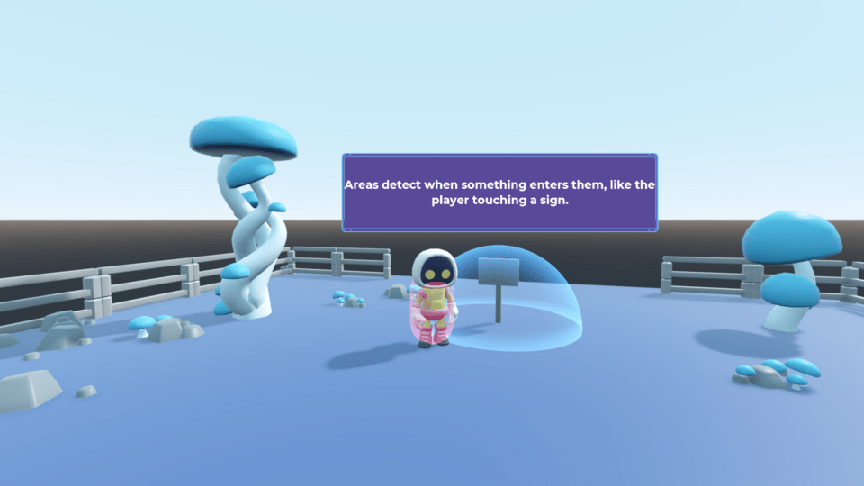

To automatically display text when the player approaches a sign, you can attach an area to it.

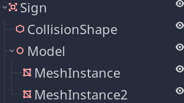

Connect the `body_entered` and `body_exited` signals to the sign’s script.

```
onready var _sign: Area2D = $Sign


func _ready() -> void:
    _text_frame.hide()
    _sign.connect("body_entered", self, "_on_Sign_body_entered")
    _sign.connect("body_exited", self, "_on_Sign_body_exited")
```

In the callback functions, you can display and hide a message, respectively.

```
func _on_Sign_body_entered(_body: PhysicsBody2D):
    show_message()


func _on_Sign_body_exited(_body: PhysicsBody2D):
    hide_message()
```

### Attracting coins to the player

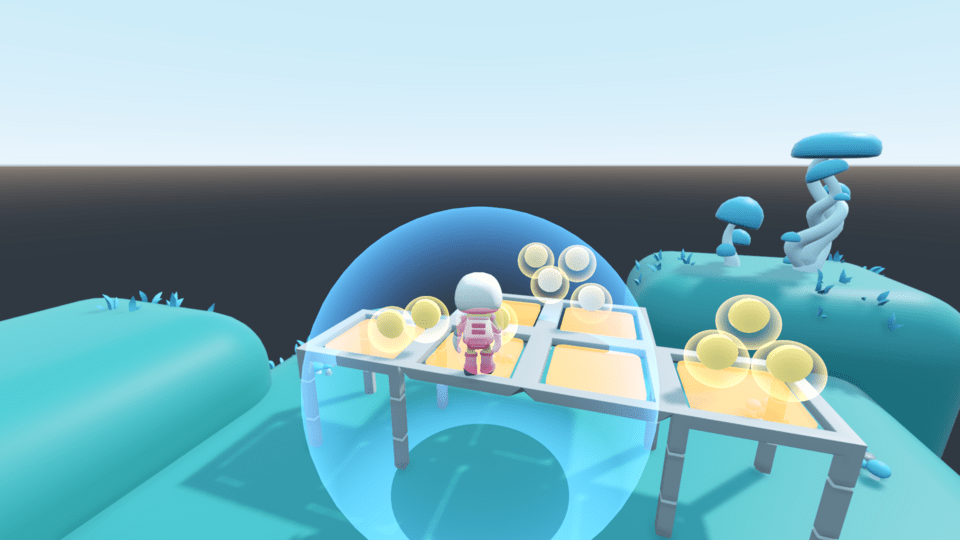

You can use two areas to attract coins to the player:

1. One, large, instanced in the player scene (the large blue sphere above).
2. The second, smaller, is the coin itself (the small yellow spheres).

There are two ways to code the coins moving towards the player. You can either use a script attached to the player or the coins.

We have a script on the coin scene to move and destroy them, as having the code on the coin allows it to manage its state and limits coupling.

We use the signal to detect when the player touches it.

```
func _ready() -> void:
    connect("body_entered", self, "_on_body_entered")

func _on_body_entered(_body: Node) -> void:
    queue_free()
```

Here’s the scene setup:

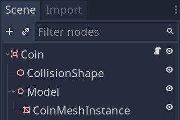

To move each coin smoothly towards the player, use the follow steering equation and `Area.get_overlapping_areas()`.

```
export var max_speed := 4.0

var _velocity := Vector3.ZERO

func _process(delta: float) -> void:
    var attractors := get_overlapping_areas()

    if attractors:
        var desired_velocity: Vector3 = (
            (attractors[0].global_transform.origin - global_transform.origin).normalized()
            * max_speed
        )
        var steering := desired_velocity - _velocity
        _velocity += steering / 14.0
    else:
        _velocity = Vector3.ZERO

    global_transform.origin += _velocity * delta
```

### Pursuing a target

In this example, we use an area to detect when the player is near an enemy. If so, the enemy moves towards the player.

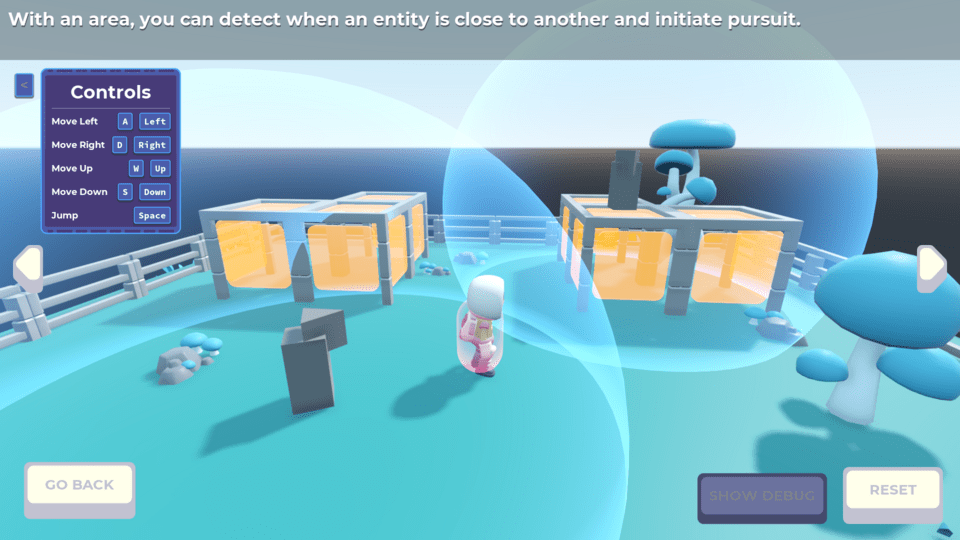

Here, all we need is an area attached to the enemy, named *DetectionArea*.

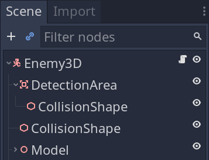

We connect the `body_entered` and `body_exited` signals from the `Area` to the root *Enemy3D* node and track the player with a variable.

```
func _on_DetectionArea_body_entered(body: Node) -> void:
    if body is Player3D:
        _target = body


func _on_DetectionArea_body_exited(body: Node) -> void:
    if body is Player3D:
        _target = null
```

If there is a target in `_physics_process()`, we use the following steering equation to move towards it.

```
func _physics_process(delta: float) -> void:
    var desired_velocity := Vector3.ZERO
    var direction := _velocity.normalized()

    if _target:
        direction = global_transform.origin.direction_to(_target.global_transform.origin)
        direction.y = 0.0
        direction = direction.normalized()
        desired_velocity = direction * speed
        _orient_character_to_direction(direction, delta)

    _y_velocity = _velocity.y
    _velocity.y = 0.0

    if is_on_floor():
        _y_velocity = 0.0
    else:
        _y_velocity += _gravity * delta

    if _blocked_check_raycast.is_colliding() and is_on_floor():
        _y_velocity = jump_force

    var steering := desired_velocity - _velocity
    _velocity += steering / drag

    _velocity.y = _y_velocity
    _velocity = move_and_slide_with_snap(_velocity, _snap, Vector3.UP, true)
```

### Opening a door with a pressure plate

Triggering game events at specific places is an essential tool for any game developer. This includes spawning enemies when a player enters a room, focusing the camera on something important, or activating a trap when the player is near.

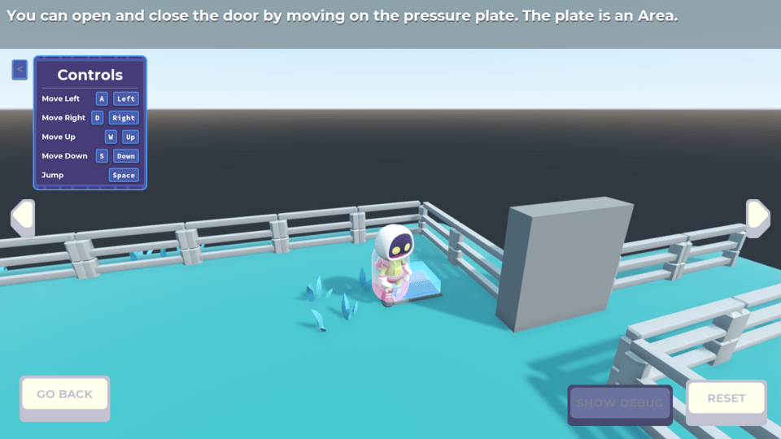

You can use an `Area` to detect the player’s presence. We used that to make a pressure plate that makes a door open or close when the player touches it.

We store a `NodePath` to the door in the pressure plate to call its `activate()` function.

```
extends Area

export var target_path: NodePath

onready var _target: Spatial = get_node_or_null(target_path)
```

We use the pressure plate’s `body_entered` signal to call the door’s `activate()` function, and play animations for pressing and releasing the plate.

```
func _ready() -> void:
    connect("body_entered", self, "_on_PressurePlate_body_entered")
    connect("body_exited", self, "_on_PressurePlate_body_exited")


func _on_PressurePlate_body_entered(_body: PhysicsBody2D):
    _tween.interpolate_property(_button_mesh, "translation", Vector3(0.0, 0.0, 0.0), Vector3(0.0, -0.10, 0.0), 0.2,Tween.TRANS_CUBIC)
    _tween.start()
    if _target and _target.has_method("activate"):
        _target.activate()


func _on_PressurePlate_body_exited(_body: PhysicsBody2D):
    _tween.interpolate_property(_button_mesh, "translation", Vector3(0.0, -0.10, 0.0), Vector3(0.0, 0.00, 0.0), 0.3,Tween.EASE_OUT)
    _tween.start()
```

### Attract rigid bodies to a black hole

In this demo, we use an `Area` to override physics properties in a sphere, turning it into a gravity point. When the player passes over a pressure plate, the `Area` sucks in rocks towards its center.

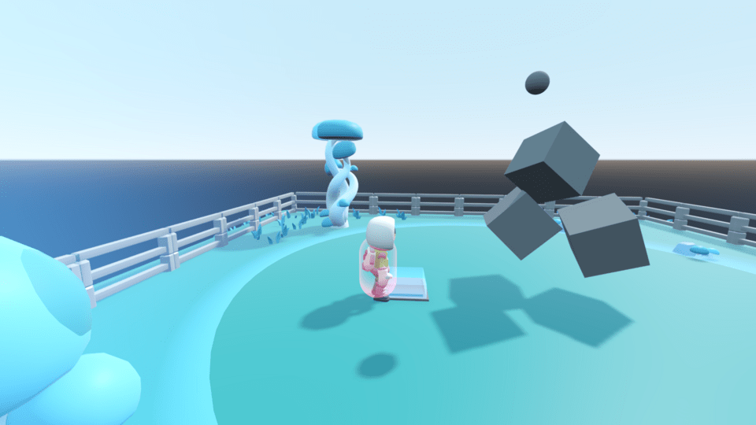

The pressure plate is the same as the door example, and the rocks are `RigidBody` nodes.

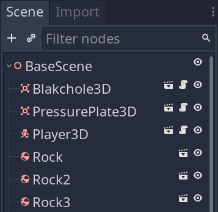

Initially, we set the *Space Override* property of the *BlackHole3D* to *Disabled*. This way, the node won’t attract the rocks when starting the scene.

We also turn on the *Gravity Point* property, so the *BlackHole3D* acts as an attractor.

We use a script to change the node’s *Space Override* upon touching the pressure plate. It causes all rigid bodies inside the area to be attracted to the area’s center.

```
func activate() -> void:
    if space_override == Area.SPACE_OVERRIDE_DISABLED:
        space_override = Area.SPACE_OVERRIDE_REPLACE
    else:
        space_override = Area.SPACE_OVERRIDE_DISABLED
```

The pressure plate works as described in the previous opening a door with a pressure plate example.

### Dealing damage with hitboxes and hurtboxes

Any precision-based game where entities can damage each other needs a way to detect whether an attack has hit its target.

For this, we use hit and hurt boxes to designate areas that respectively cause and receive damages.

[figure not shown]

**Note:** The terms hitbox and hurtbox are not standardized across the industry, so which is which may vary from game to game.

The principle behind having a hitbox and a hurtbox is that when a hitbox touches a hurtbox, the owner of the hurtbox takes damage.

We have a player scene with an `Area` representing our hitbox and an enemy scene with an area that is our hurtbox.

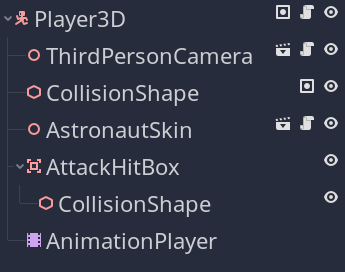

In the player scene, we disable the `CollisionShape` of the *AttackHitBox* `Area`. We enable it only when the player presses the attack button for the duration of a short attack animation.

```
func attack() -> void:
    _model.attack()
    _hit_box_collision.set_deferred("disabled", false)
    yield(_model.anim_player, "animation_finished")
    _hit_box_collision.set_deferred("disabled", true)
```

On the enemies, we connect the `area_entered` signal of the hurtbox area to a function that calls `take_damage()`. `take_damage()` plays a death animation, disables collisions and starts a particle system.

```
func _on_HurtBox_area_entered(area: Area) -> void:
    take_damage()

func take_damage() -> void:
    _animation_player.play("Die")
    _collision_shape.set_deferred("disabled", true)
    _hurtbox.set_deferred("monitoring", false)
    _hitbox.set_deferred("monitoring", false)
    set_physics_process(false)
    _smoke_particles.emitting = true
```

### Opening chests with contextual inputs

After checking if a player is close enough to an object, the next step is to listen for keypresses to activate that object. Almost every game with interactable objects will need contextual inputs like this.

A clear example of this is a chest that the player opens or closes by pressing a key.

We attach an `Area` to the chest to detect if the character is close enough when pressing the interaction key.

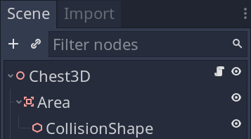

```
func _unhandled_input(event: InputEvent) -> void:
    if _animation_player.is_playing():
        return
    if event.is_action_pressed("interact"):
        for body in _area.get_overlapping_bodies():
            if body is Player3D:
                toggle_open()
```

## Your questions

### What can an Area detect?

The `Area` node cannot detect any other type of body.

### When should I use an Area instead of a StaticBody or KinematicBody?

Unlike `KinematicBody`, `RigidBody`, and `StaticBody`, the `Area` node doesn’t handle collisions through the physics engine. It only detects when something enters, overlaps, or leaves its `CollisionShape`.

Use an `Area` if you need to:

- Detect when objects enter or exit an area.
- Detect when the mouse enters or exits an area.
- Create an area where physics behave differently, such as lowering gravity underwater. This feature affects `RigidBody` nodes.
- Have the game’s audio flow through a specific mixer channel, such as applying a low-pass audio filter underwater.

In contrast, `StaticBody`, `KinematicBody`, and `RigidBody` are physics bodies. They inherit properties from `PhysicsBody`, and don’t allow overlap. When a collision happens, the physics engine pushes kinematic and rigid bodies outside walls and other bodies.

Here’s when to use them instead of `Area`:

- Use a `StaticBody` for solid walls or grounds, even for objects that affect the player’s movement, like conveyor belts.
- Use a `KinematicBody` for any physical object you want to move manually, with fine control. This node is the most commonly used for characters.
- Use a `RigidBody` for any physical object you want to move using physics properties like gravity and forces. While you typically use them for physics games like *Angry Birds*, some studios also use rigid body physics for all their game characters.

### Telling bodies apart

You now know how to detect that a body entered an area, but how can you tell *which* body?

Common solutions involve:

- Using a class name and the `is` keyword.
- Using Godot’s group feature.
- Using duck typing.
- Using nodes and composition.

For more information, have a look at the Area2D guide, which describes each case in full.

### What are the different signals for?

The main signals you’ll use with `Area` are:

- `area_entered(area: Area)`: detects another `Area`.
- `body_entered(body: PhysicsBody)`: detects a `StaticBody`, `KinematicBody`, or `RigidBody`.

Other signals you may use are:

- `area_shape_entered(area_id: int, area: Area, area_shape: int, local_shape: int)`.
- `body_shape_entered(body_id: int, body: Node, body_shape: int, local_shape: int)`.

Which report specific shapes in the overlapping bodies (remember, there can be multiple shapes per body).

### Determining who handles the action

Now that you can detect bodies and know what they are, you may ask: which of the two bodies should handle the interaction?

A good question to ask yourself is: out of all my options, which can I remove from the scene more easily?

Let’s take the example of an enemy attacking the player. Depending on the enemy’s power, the player should lose `1`, `2`, or `3` health points.

If the *Player* object needs to verify which enemy is attacking to affect its health, your game will break when you rename the enemy or remove it it; you will need to adjust the *Player*’s code.

But if the `Enemy` object affects the player, nothing else needs to change when deleting the enemy.

In that case, the second choice is better.

### Using a third object to represent interactions

Some object-oriented programming guides recommend creating a third object representing a hit. While there might be cases where this can help seperate code into more logical sections, you need to think about if you actually need it.

If you are making a deep RPG with complex damage calculations, representing a hit as an object may be helpful. But it is unnecessary complexity in most games.

A mistake many make is to think having a third object decouples the first two. But typically, it lengthens the dependency chain.

Sticking to the example above, you initially have a direct dependency between `Player` and `Enemy`.

If you add a new `Hit` object in-between, you add an extra dependency in the chain. Now, both `Enemy` and `Player` are linked to `Hit`, so there are two class dependencies instead of one.

That’s why we recommend only considering adding an extra object like this when it starts to offer concrete benefits in *your* game projects.

> Nodes mentioned in this tutorial: [Area](https://docs.godotengine.org/en/stable/classes/class_area.html), [CollisionShape](https://docs.godotengine.org/en/stable/classes/class_collisionshape.html), [CollisionPolygon](https://docs.godotengine.org/en/stable/classes/class_collisionpolygon.html), [KinematicBody](https://docs.godotengine.org/en/stable/classes/class_kinematicbody.html).